# Online Machine Learning in JAGS

## Introduction

Online machine learning is a branch of machine learning where the training samples arrive sequentially (compared to batch processing). The model parameters are dynamically updated with the arrival new data. More details can be found [here](https://en.wikipedia.org/wiki/Online_machine_learning). Several tools like Vowpal Wabbit, Scikit Learn provide support for online learning. In this article we look at an alternate approach using JAGS.

**JAGS** (Just Another Gibbs Sampler) is a DSL for model specification and an MCMC sampler. It is used to build hierarchical Bayesian models.

## Simple example

In this article we will look at a simple example of inferring the probability of heads from a sequence of coin tosses. For the purposes of this example, the data will arrive in 2 batches - `data1` and `data2`. The model will be sequentially updated. First, the model specification in JAGS. Each coin toss is Bernoulli distributed and the prior on `p` is uniform distribution.

```r
model <- "model {
            for (i in 1:N) {
              toss[i] ~ dbern(p)
            }
            p ~ dbeta(a,b)
          }"
```

Set the initial data, compile the model and draw samples from posterior distribution for the first batch of data.

```r
a1 <- 1
b1 <- 1
data1 <- list(toss = c(0,0,1,1), N = 4, a = a1, b = b1)
# compile the model
model1 <- jags.model(textConnection(model), data1)
# sample from the posterior p|toss[1:N]
out1 <- jags.samples(model1, "p", n.iter = 1000)
```

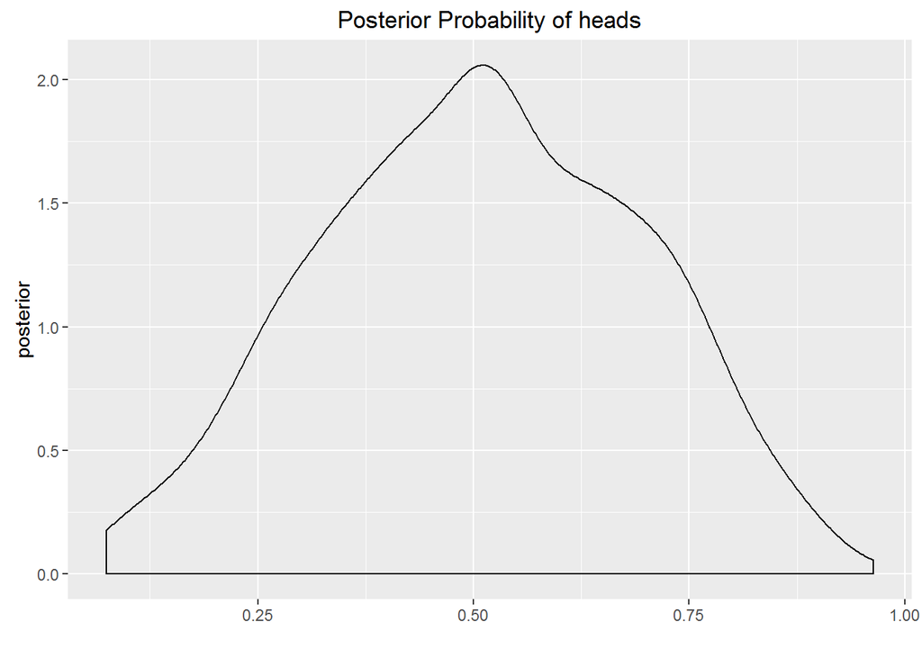

The posterior is the conjugate prior of Bernoulli distribution and hence beta distributed. But choosing a parametric family for the posterior is not always appropriate.

```r
library(MASS)
fit <- fitdistr(out1$p, "beta", start = list(shape1=a1, shape2=b1))
a2 <- fit$estimate[[1]]
b2 <- fit$estimate[[2]]
```

Update the model with new data and repeat the process

```r
data2 <- list(toss=c(0,1,1,0), N=4, a=a2, b=b2)
model2 <- jags.model(textConnection(model), data2)
out2 <- jags.samples(model2, "p", n.iter=1000)
```

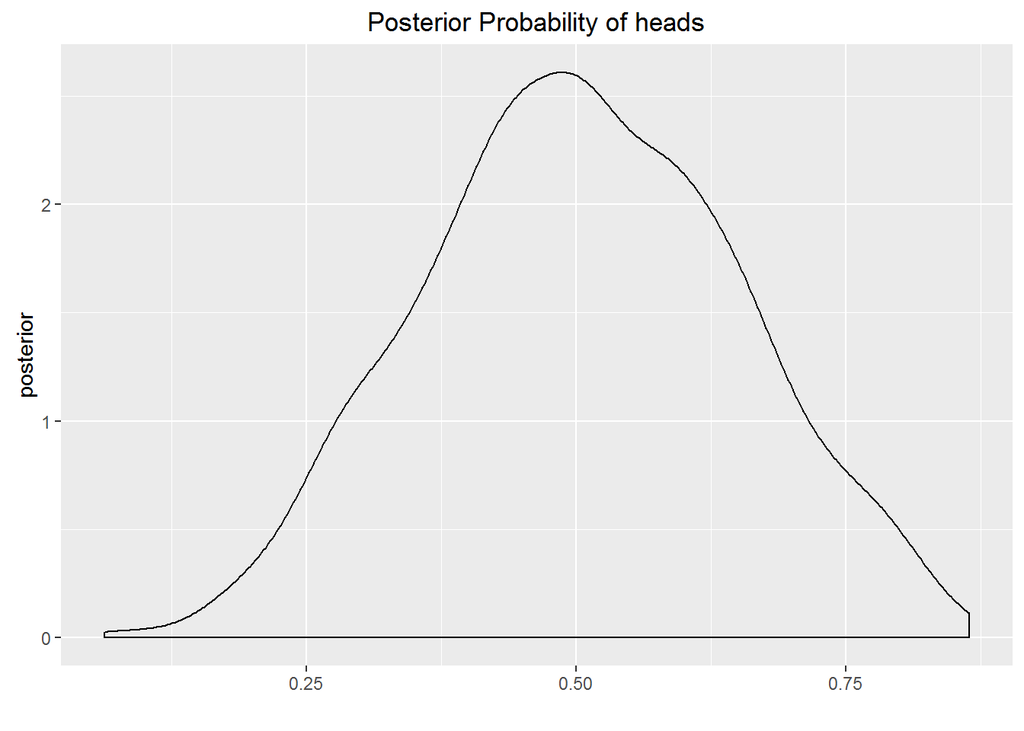